# analisis emocionalidad texto

julieth vanessa tovar torres

2022-11-17

# *1) POEMA “No voy a pedirte nada – Frida Kahlo”*

FRIDA KAHLO  
Magdalena Carmen Frida Kahlo Calderón, conocida como Frida Kahlo, fue una pintora mexicana. Su obra gira temáticamente en torno a su biografía y a su propio sufrimiento.  
Fue autora de 150 obras, principalmente autorretratos, en los que proyectó sus dificultades por sobrevivir.  
Nacimiento 6 de Julio de 1907, Coyoacan, Ciudad de Mexico, Mexico  
Fallecimiento 13 de Julio de 1954, Coyoacan, Ciudad de Mexico, Mexico  
Conyuge Diego Rivera

NO VOY A PEDIRTE NADA  
No te voy a pedir que me des un beso.  
Ni que me pidas perdón cuando creo que lo has hecho mal o que te has equivocado.  
Tampoco voy a pedirte que me abraces cuando más lo necesito, o que me invites a cenar  
el día de nuestro aniversario.  
No te voy a pedir que nos vayamos a recorrer mundo, a vivir nuevas experiencias, y  
mucho menos te voy a pedir que me des la mano cuando estemos en mitad de la ciudad.  
No te voy a pedir que me digas lo guapa que voy, aunque sea mentira, ni que me escribas  
nada bonito.  
No voy a pedirte que aparezcas en la puerta de mi casa con una rosa como tanto me  
gustaría.  
Tampoco te voy a pedir que me llames para contarme qué tal te fue la noche, ni que me  
digas que me echas de menos.  
No te voy a pedir que me rías las gracias, ni que hagas el tonto conmigo cuando mis  
ánimos están por los suelos, y por supuesto, no te pediré que me apoyes en mis  
decisiones.  
Tampoco te voy a pedir que me escuches cuando tengo mil historias que contarte. No te  
voy a pedir que hagas nada, ni siquiera que te quedes a mi lado para siempre.  
Porque si tengo que pedírtelo, ya no lo quiero.

# *2) CONTEXTUALIZACION PREVIA AL ANALISIS*

el poema anterior me genera las siguientes emociones:  
trizteza  
aversion  
ira  
miedo

tambien se dan estas emociones:  
desamor  
soledad  
abandono  
lastima  
comprension  
resignacion  
libertad  
fortaleza

sentimiento:  
negativo

# *3) NUBE DE PALABRAS CON LAS PALABRAS MAS FRECUENTES*

librerias necesarias para la ejecucion del resto de puntos

```r
library(NLP)
library(tm)
library(SnowballC)
library(RColorBrewer)
library(wordcloud)
library(wordcloud2)
library(ggplot2)
library(dplyr)
library(readr)
library(tokenizers)
library(tidyverse)
library(syuzhet)
library(lubridate)
library(scales)
```

creacion del texto y estandarizacion/eliminacion de caracteres

```r
poema <- paste("No te voy a pedir que me des un beso.
Ni que me pidas perdón cuando creo que lo has hecho mal o que te has equivocado.
Tampoco voy a pedirte que me abraces cuando más lo necesito, o que me invites a cenar el dia de nuestro aniversario.
No te voy a pedir que nos vayamos a recorrer mundo, a vivir nuevas experiencias, y mucho menos te voy a pedir que me des la mano cuando estemos en mitad de la ciudad.
No te voy a pedir que me digas lo guapa que voy, aunque sea mentira, ni que me escribas nada bonito.
No voy a pedirte que aparezcas en la puerta de mi casa con una rosa como tanto me gustaria.
Tampoco te voy a pedir que me llames para contarme qué tal te fue la noche, ni que me digas que me echas de menos.
No te voy a pedir que me rías las gracias, ni que hagas el tonto conmigo cuando mis ánimos estan por los suelos, y por supuesto, no te pediré que me apoyes en mis decisiones.
Tampoco te voy a pedir que me escuches cuando tengo mil historias que contarte. No te voy a pedir que hagas nada, ni siquiera que te quedes a mi lado para siempre.
Porque si tengo que pedírtelo, ya no lo quiero.")
poem<- poema%>%
  removePunctuation()%>%
  str_to_lower()%>%
  str_replace_all(., "[[:cntrl:]]"," ")%>%
  removeWords(., words = stopwords("spanish"))%>%
  removeWords(., words = c("usted", "pues", "tal", "tan", "asi", "dijo", "como", "sino",
                           "entonces", "aunque", "que"))

coleccion<- poem%>%
  VectorSource()%>%
  Corpus()
```

creacion de la nube de palabras

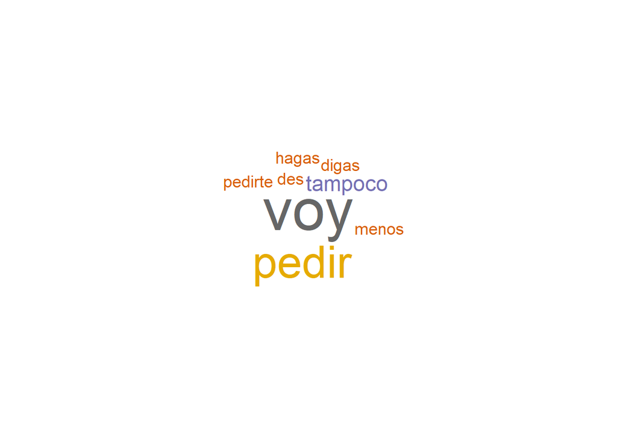

```r
wordcloud(coleccion,
          min.freq = 2, #frecuencia minima (que aparezcan 5 veces en el texto)
          max.words = 80, #frecuencia maxima
          random.order = FALSE,
          colors = brewer.pal(name = "Dark2", n=8))
```

# *4) GRAFICA DE EMOCIONES*

```r
trad_emociones <- function(cadena){
  case_when(
    cadena == "anger"~"ira",
    cadena == "anticipation"~"anticipación",
    cadena == "disgust"~"aversión",
    cadena == "fear"~"miedo",
    cadena == "joy"~ "alegría",
    cadena == "sadness"~"tristeza",
    cadena == "surprise"~"asombro",
    cadena == "trust"~"confianza",
    cadena == "negative"~"negativo",
    cadena == "positive"~"positivo",
    TRUE ~ cadena
  )
}
resultadopoem <- get_nrc_sentiment(poem, language = "spanish")
resultadopoem
```

```
##   anger anticipation disgust fear joy sadness surprise trust negative positive
## 1     3            1       3    2   3       3        2     2       10        4
```

```r
sentimientospoem <- resultadopoem%>%
  gather(sentimiento, cantidad)%>%
  mutate(sentimiento = trad_emociones(sentimiento))%>%
  group_by(sentimiento) %>%
  summarise(total = sum(cantidad))
sentimientospoem
```

```
## # A tibble: 10 × 2
##    sentimiento  total
##    <chr>        <dbl>
##  1 alegría          3
##  2 anticipación     1
##  3 asombro          2
##  4 aversión         3
##  5 confianza        2
##  6 ira              3
##  7 miedo            2
##  8 negativo        10
##  9 positivo         4
## 10 tristeza         3
```

```r
indexpoem<- sentimientospoem$sentimiento %in% c("positivo", "negativo")
indexpoem
```

```
##  [1] FALSE FALSE FALSE FALSE FALSE FALSE FALSE  TRUE  TRUE FALSE
```

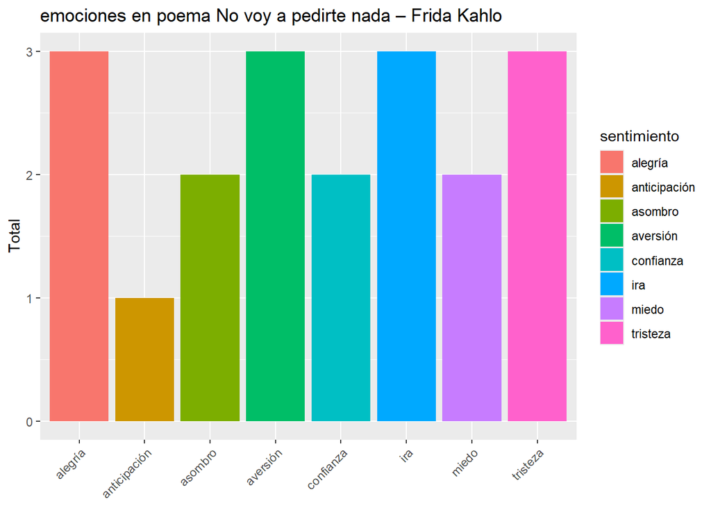

```r
sentimientospoem[!indexpoem,]%>%
  ggplot()+
  aes(sentimiento, total)+
  geom_bar(aes(fill =sentimiento), stat = "identity")+
  theme(axis.text.x = element_text(angle = 45, hjust =  1))+
  xlab(NULL) +
  ylab("Total") +
  ggtitle("emociones en poema No voy a pedirte nada – Frida Kahlo")
```

# *5) GRAFICA DE SENTIMIENTOS*

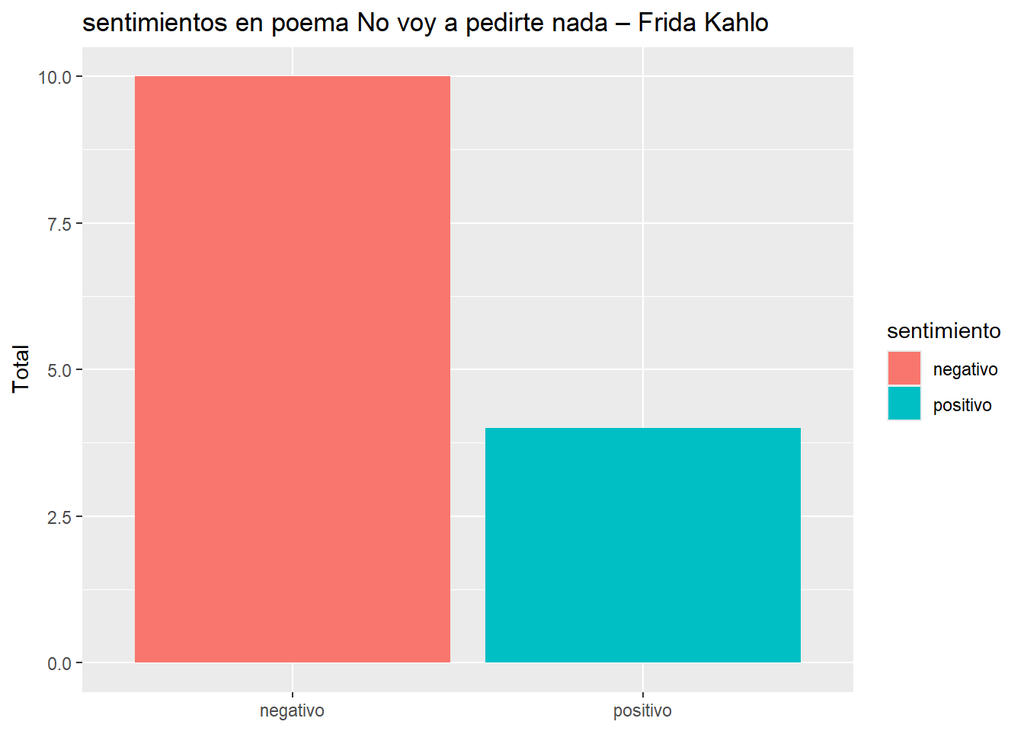

```r
sentimientospoem[indexpoem,]%>%
  ggplot()+
  aes(sentimiento, total)+
  geom_bar(aes(fill =sentimiento), stat = "identity")+
  xlab(NULL) +
  ylab("Total") +
  ggtitle("sentimientos en poema No voy a pedirte nada – Frida Kahlo")
```

# *6) RELACION ENCONTRADO CON EXPUESTO PUNTO 2*

los resultados del analisis de R respecto a las emociones que produce el poema estan  
bastante cercanos, a pesar que hay discrepancias como en alegria y confianza (lo cual  
podria ser confianza en ella misma) emociones las cuales realmente no produce en el  
lector.

# *1) ANALISIS CANCION “Ilegal-Canción de Cultura Profética”*

CULTURA PROFETICA  
Cultura Profética es una banda de reggae originaria de Puerto Rico que hizo su debut en  
1996. Son reconocidos por su particular estilo con toques de roots reggae, su tributos  
a Bob Marley,  y una discografía rica en exploraciones sonoras.  
e rindieron tributo al legendario músico de reggae Bob Marley, emulando sus canciones  
más famosas casi a la perfección. Boris Bilbraut, el baterista de la banda hizo de voz  
principal en este exitoso tributo.

2010 es el año en que sale a la venta La Dulzura su más reciente producción  
discográfica que trajo muchos éxitos hasta día de hoy, bajo el sello de La Mafafa, es  
una producción de Willy Rodríguez (voz y bajo), Omar Silva (guitarra y bajo), Eliut  
González (guitarra), Boris Bilbraut (batería y voz) y Juan C. Sulsona (teclado).  
Origen: Puerto Rico (1996)  
Género: Reggae  
Premios: Premio Grammy Latino al Mejor Álbum de Música Alternativa  
Sellos discográficos: Tuff Gong, LUAR MUSIC

ILEGAL  
Tener tus ojos  
Debe ser ilegal  
Y más si cuando miras solo inspiras a pecar  
Esa sonrisa peculiar  
De jugar a tentar, letal  
Esos dotes que sí sabes como usar para matar  
Te has armado de forma perfecta  
Para hacerme agonizar  
Tan muerte lenta  
Mientras tu boca violenta revienta  
Dentro de mi boca como un rayo una tormenta  
Tus manos calientan piel  
Solo de rozarla  
Mis manos van jugando a conocer tu espalda  
Con toda la calma  
Se alarga  
La delicia de mi expedición hacia tus nalgas  
Y no hay más que una sola versión  
Una sola muestra total de perfección  
Llenas de luz la habitación con tus brillos de neón  
Y yo sin trabajo suelto así un último botón, pienso  
Tan solo las doce y no se escuchan voces  
Solo gemidos finos, sonidos del goce  
Y para cerrar la noche  
Con broche de oro  
Yo te llego al oído y susurro este coro  
Eso no fue nada, no  
Ya estoy en confianza, negra  
Si me regalas la mañana  
Te llevo hasta la noche plena  
Eso no fue nada, no, oh  
Ya estoy en confianza, negra  
Si me regalas la mañana  
Ah-ah-ah-ah  
Te llevo hasta la noche plena  
Tus manos calientan piel  
Solo de rozarla  
Mis manos van jugando a conocer tu espalda  
Con toda la calma  
Se alarga  
La delicia de mi expedición hacia tus nalgas  
Y no hay más que una sola versión  
Una sola muestra total de perfección  
Llenas de luz la habitación con tus brillos de neón  
Y yo  
Lelo, disfrutando del juego  
Eso no fue nada, no  
Ya estoy en confianza, negra  
Si me regalas la mañana  
Te llevo hasta la noche plena  
Eso no fue nada, no  
Ya estoy en confianza, negra  
Si me regalas la mañana  
Ah-ah-ah-ah  
Te llevo hasta la noche plena  
Te llevo hasta la noche plena  
Ah  
Ay, te llevo hasta la noche, (Ah)  
(Te llevo hasta la noche plena)  
Ah-ah-ah  
Te llevo hasta la noche plena

# *2) CONTEXTUALIZACION PREVIA AL ANALISIS*

el poema anterior me genera las siguientes emociones:  
alegria  
asombro  
confianza

tambien se dan estas emociones:  
seduccion  
deseo  
tension  
ansiedad  
sorpresa

sentimiento:  
positivo

# *3) NUBE DE PALABRAS CON LAS PALABRAS MAS FRECUENTES*

creacion del texto y estandarizacion/eliminacion de caracteres

```r
poemai <- paste("ILEGAL
Tener tus ojos Debe ser ilegal Y más si cuando miras solo inspiras a pecar Esa sonrisa peculiar De jugar a tentar, letal Esos dotes que si sabes como usar para matar Te has armado de forma perfecta Para hacerme agonizar Tan muerte lenta Mientras tu boca violenta revienta Dentro de mi boca como un rayo una tormenta Tus manos calientan piel Solo de rozarla Mis manos van jugando a conocer tu espalda
Con toda la calma Se alarga La delicia de mi expedición hacia tus nalgas Y no hay mas que una sola version Una sola muestra total de perfeccion
Llenas de luz la habitacion con tus brillos de neon Y yo sin trabajo suelto asi un ultimo boton, pienso Tan solo las doce y no se escuchan voces Solo gemidos finos, sonidos del goce Y para cerrar la noche Con broche de oro Yo te llego al oído y susurro este coro Eso no fue nada, no Ya estoy en confianza, negra Si me regalas la mañana Te llevo hasta la noche plena Eso no fue nada, no, oh Ya estoy en confianza, negra
Si me regalas la mañana Ah-ah-ah-ah Te llevo hasta la noche plena Tus manos calientan piel Solo de rozarla Mis manos van jugando a conocer tu espalda Con toda la calma Se alarga La delicia de mi expedición hacia tus nalgas Y no hay mas que una sola version
Una sola muestra total de perfeccion Llenas de luz la habitacion con tus brillos de neon Y yo Lelo, disfrutando del juego
Eso no fue nada, no Ya estoy en confianza, negra
Si me regalas la mañana Te llevo hasta la noche plena
Eso no fue nada, no Ya estoy en confianza, negra Si me regalas la mañana Ah-ah-ah-ah Te llevo hasta la noche plena Te llevo hasta la noche plena Ah Ay, te llevo hasta la noche, (Ah) (Te llevo hasta la noche plena) Ah-ah-ah Te llevo hasta la noche plena")
poemi<- poemai%>%
  removePunctuation()%>%
  str_to_lower()%>%
  str_replace_all(., "[[:cntrl:]]"," ")%>%
  removeWords(., words = stopwords("spanish"))%>%
  removeWords(., words = c("usted", "pues", "tal", "tan", "asi", "dijo", "como", "sino","entonces", "aunque", "que","ah", "oh"))
poemi<- chartr("ÁÉÍÓÚ","AEIOU", toupper(poemi)) #quitar tildes

coleccioni<- poemi%>%
  VectorSource()%>%
  Corpus()
```

creacion de la nube de palabras

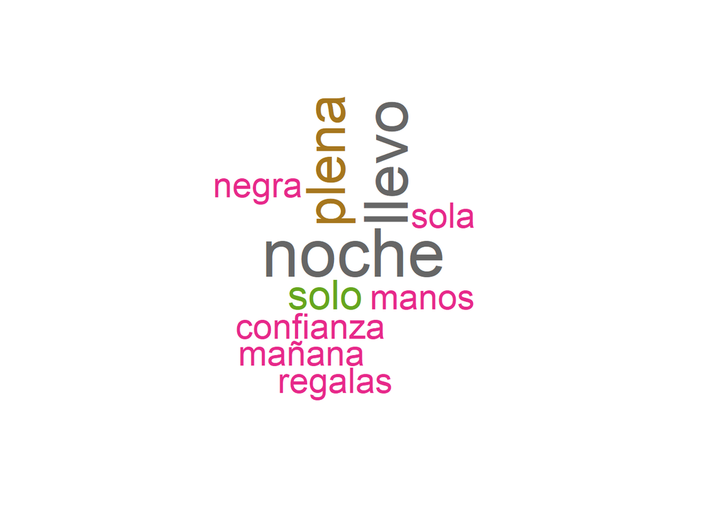

```r
wordcloud(coleccioni,
          min.freq = 3, #frecuencia minima (que aparezcan 3 veces en el texto)
          max.words = 80, #frecuencia maxima
          random.order = FALSE,
          colors = brewer.pal(name = "Dark2", n=12))
```

# *4) GRAFICA DE EMOCIONES*

```r
trad_emociones <- function(cadena){
  case_when(
    cadena == "anger"~"ira",
    cadena == "anticipation"~"anticipacion",
    cadena == "disgust"~"aversion",
    cadena == "fear"~"miedo",
    cadena == "joy"~ "alegria",
    cadena == "sadness"~"tristeza",
    cadena == "surprise"~"asombro",
    cadena == "trust"~"confianza",
    cadena == "negative"~"negativo",
    cadena == "positive"~"positivo",
    TRUE ~ cadena
  )
}
resultadopoemi <- get_nrc_sentiment(poemi, language = "spanish")
resultadopoemi
```

```
##   anger anticipation disgust fear joy sadness surprise trust negative positive
## 1     7            6       7    8   6       7        6     7       14       12
```

```r
sentimientospoemi <- resultadopoemi%>%
  gather(sentimiento, cantidad)%>%
  mutate(sentimiento = trad_emociones(sentimiento))%>%
  group_by(sentimiento) %>%
  summarise(total = sum(cantidad))
sentimientospoemi
```

```
## # A tibble: 10 × 2
##    sentimiento  total
##    <chr>        <dbl>
##  1 alegria          6
##  2 anticipacion     6
##  3 asombro          6
##  4 aversion         7
##  5 confianza        7
##  6 ira              7
##  7 miedo            8
##  8 negativo        14
##  9 positivo        12
## 10 tristeza         7
```

```r
indexpoemi<- sentimientospoemi$sentimiento %in% c("positivo", "negativo")
indexpoemi
```

```
##  [1] FALSE FALSE FALSE FALSE FALSE FALSE FALSE  TRUE  TRUE FALSE
```

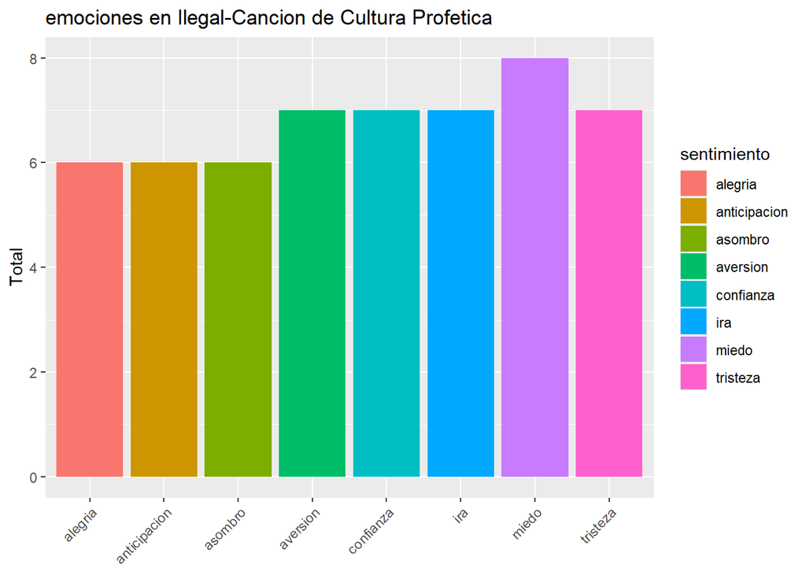

```r
sentimientospoemi[!indexpoemi,]%>%
  ggplot()+
  aes(sentimiento, total)+
  geom_bar(aes(fill =sentimiento), stat = "identity")+
  theme(axis.text.x = element_text(angle = 45, hjust =  1))+
  xlab(NULL) +
  ylab("Total") +
  ggtitle("emociones en Ilegal-Cancion de Cultura Profetica")
```

# *5) GRAFICA DE SENTIMIENTOS*

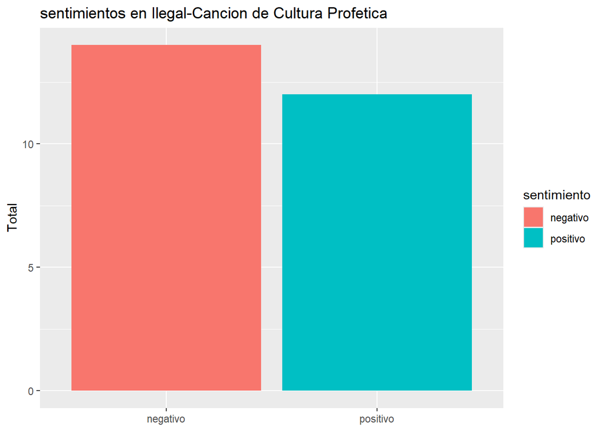

```r
sentimientospoemi[indexpoemi,]%>%
  ggplot()+
  aes(sentimiento, total)+
  geom_bar(aes(fill =sentimiento), stat = "identity")+
  xlab(NULL) +
  ylab("Total") +
  ggtitle("sentimientos en Ilegal-Cancion de Cultura Profetica")
```

# *6) RELACION ENCONTRADO CON EXPUESTO PUNTO 2*

los resultados del analisis de R respecto a las emociones que produce la cancion estan  
bastante lejanos, ya que evidencia los sentimientos como negativos aun cuando no es la sensacion que le produce a la audiencia, en cuanto a las emociones tambien esta errado ya que lo que mas evidencia es miedo cuando no deberia ser asi ya que es una cancion de seduccion que a pesar que puede tener notaciones un poco sombrias no deberia generar temor ni algo por el estilo asi como tampoco ira, vaersion y tristeza.